# E-Commerce Text Classification

In this project we will attempt to classify e-commerce products into the following four categories: `Books`, `Clothing & Accessories`, `Electronics`, and `Household`. Our dataset consists of about 50,000 rows of categorized data that consists of a label which represents the four categories above and a description which describes the product.

As we proceed through this project, we will cover the following steps:

1. Exploratory Data Analysis
2. Text Normalization
3. Final Preparation (encoding and splitting)
4. Word2Vec Model
5. GloVe Model
6. Conclusion

```python
import pandas as pd
import numpy as np
import os, cv2
from glob import glob

# Plotting and visualization
import matplotlib.pyplot as plt
import seaborn as sns

from sklearn.model_selection import train_test_split
from sklearn.metrics import confusion_matrix, classification_report

# NLP
import string, re, nltk
from string import punctuation
from nltk.tokenize import word_tokenize, sent_tokenize
from nltk.corpus import stopwords
from nltk.stem import WordNetLemmatizer

import spacy
from tqdm import tqdm
from collections import Counter

nltk.download('punkt')
nltk.download('stopwords')

import tensorflow as tf
import tensorflow_hub as hub
from tensorflow import keras
from tensorflow.keras import layers, losses, optimizers, callbacks

from tensorflow.keras.preprocessing.text import Tokenizer
from tensorflow.keras.preprocessing.sequence import pad_sequences

from gensim.models import KeyedVectors

import gc
```

#### This is a useful code for identifying if tensorflow has accurately found your GPU and update memory growth.

```python
### make sure tensorflow is using GPU
physical_devices = tf.config.experimental.list_physical_devices('GPU')
print('Num GPUs Available: ' , len(physical_devices))
tf.config.experimental.set_memory_growth(physical_devices[0], True)
```

```
Num GPUs Available:  1
```

## Exploratory Data Analysis

To kick off this project, lets start by reviewing the data and obtain a basic understanding of the data. We will start by loading the data, then proceed to analyze the data by checking the number of words or characters per instance of data and more.

### Loading the Data

We will start by loading the data directly from the source. This dataset consists of 50,000 listings that have a label and a description. These labels fall into 4 categories of `Household`, `Books`, `Electronics`, and `Clothing & Accessories`. We start by loading the data directly from the source to enable the code to be more replicatable. Next we check basic values. We see that the data has some duplicates based off the frequency being >1 for description. We also see that we have 1 null value which we will drop.

```python
# Loading and customizing the data
data = pd.read_csv('https://zenodo.org/records/3355823/files/ecommerceDataset.csv',
    names = ['label', 'description'])
data
```

|  | label | description |
| --- | --- | --- |
| 0 | Household | Paper Plane Design Framed Wall Hanging Motivat... |
| 1 | Household | SAF 'Floral' Framed Painting (Wood, 30 inch x ... |
| 2 | Household | SAF 'UV Textured Modern Art Print Framed' Pain... |
| 3 | Household | SAF Flower Print Framed Painting (Synthetic, 1... |
| 4 | Household | Incredible Gifts India Wooden Happy Birthday U... |
| ... | ... | ... |
| 50420 | Electronics | Strontium MicroSD Class 10 8GB Memory Card (Bl... |
| 50421 | Electronics | CrossBeats Wave Waterproof Bluetooth Wireless ... |
| 50422 | Electronics | Karbonn Titanium Wind W4 (White) Karbonn Titan... |
| 50423 | Electronics | Samsung Guru FM Plus (SM-B110E/D, Black) Colou... |
| 50424 | Electronics | Micromax Canvas Win W121 (White) |

50425 rows × 2 columns

```python
data.describe()
```

|  | label | description |
| --- | --- | --- |
| count | 50425 | 50424 |
| unique | 4 | 27802 |
| top | Household | Think & Grow Rich About the Author NAPOLEON HI... |
| freq | 19313 | 30 |

```python
data.info()
```

```
<class 'pandas.core.frame.DataFrame'>
RangeIndex: 50425 entries, 0 to 50424
Data columns (total 2 columns):
 #   Column       Non-Null Count  Dtype
---  ------       --------------  -----
 0   label        50425 non-null  object
 1   description  50424 non-null  object
dtypes: object(2)
memory usage: 788.0+ KB
```

```python
data = data.dropna()
```

### Fixing some incorrect Labels

As we proceeded further in our analysis, I noticed that some of the descriptions did not match up with the label. The biggest one to note was books being classified outside of books. After some testing, looking for the word `author` with a space at the end to ensure it is a unique word returned only books. While this may not fix everything, it will enable us to have a cleaner dataset that predicts correct more often.

```python
pd.set_option('display.max_colwidth', None)
data[(data['label']!='Books') & data['description'].str.lower().str.contains('author ')]
```

|  | label | description |
| --- | --- | --- |
| 45 | Household | Artworks: Meaning, Definition, Value Review "Artworks offers a thorough, balanced, and incisive account of the important positions on this issue and makes an interesting and persuasive case for a posi… |
| 107 | Household | Doodle Stitching Transfer Pack: 300+ Embroidery Patterns About the Author Aimee Ray's work is fresh, bright, sweet and clever, and can be found in numerous publications. She is the bestselling author … |
| 110 | Household | Doodle Stitching Transfer Pack: 300+ Embroidery Patterns About the Author Aimee Ray's work is fresh, bright, sweet and clever, and can be found in numerous publications. She is the bestselling author … |
| 122 | Household | The Overlocker Technique Manual: The Complete Guide to Serging and Decorative Stitching Review Aug 2014 This is the third of the books that Search Press sent to me for review purposes. I chose to revi… |
| 747 | Household | The Fairytale Hairdresser and Rapunzel: Playbox Review "With bold line, strong colour pictures and witty, easy-to-read narrative, this is an ideal book for the newly-independent reader" (Irish Examine… |
| ... | ... | ... |
| 49447 | Electronics | CBSE Chemistry Chapterwise Solved Papers Class 12th About the Author An editorial team of highly skilled professionals at Arihant, works hand in glove to ensure that the students receive the best and … |
| 49526 | Electronics | Mighty Mount Kilimanjaro: 41 (Geronimo Stilton) About the Author Geronimo Stilton is the publisher of The Rodent's Gazette, Mouse Island's most famouse newspaper. In his spare time, Mr. Stilton enjoys… |
| 49536 | Electronics | Mighty Mount Kilimanjaro: 41 (Geronimo Stilton) About the Author Geronimo Stilton is the publisher of The Rodent's Gazette, Mouse Island's most famouse newspaper. In his spare time, Mr. Stilton enjoys… |
| 49542 | Electronics | Mighty Mount Kilimanjaro (Geronimo Stilton) About the Author Geronimo Stilton is the publisher of The Rodent's Gazette, Mouse Island's most famouse newspaper. In his spare time, Mr. Stilton enjoys col… |
| 50361 | Electronics | How an iPhone made me the youngest billionaire Based on a true story where the author incurs many failures in life but believes that failure comes to those who deserve something bigger. He continuousl… |

182 rows × 2 columns

```python
data.loc[(data['label'] != 'Books') & (data['description'].str.lower().str.contains('author ', na=False)), 'label'] = 'Books'
pd.set_option('display.max_colwidth', 500)
```

### Label Frequency Distribution

Next lets check the label frequency distribution for the dataset. We see that household is the most comming with clothing being the least common. Overall nothing seems too extreme so we can proceed. While the dataset is not perfectly balanced, the distribution seems enough to prevent the model from ignoring a class, as such I do not think it will be necessary to rebalance the dataset.

```
Data Shape: (50424, 2)
label
Household                 19251
Books                     12002
Electronics               10513
Clothing & Accessories     8658
Name: count, dtype: int64
```

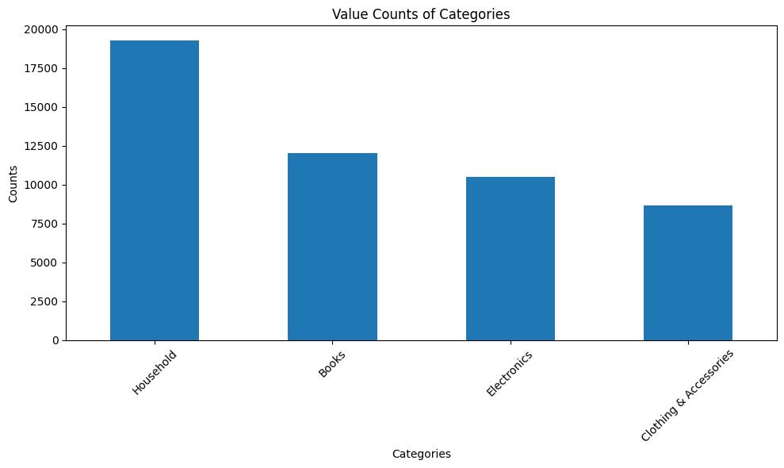

```python
value_counts = data['label'].value_counts()
print(f'Data Shape: {data.shape}')
print(value_counts)

plt.figure(figsize=(10, 6))
value_counts.plot(kind='bar')
plt.xlabel('Categories')
plt.ylabel('Counts')
plt.title('Value Counts of Categories')
plt.xticks(rotation=45)
plt.tight_layout()
```

### Character and Word Frequency

Next lets check character and word freqency for the dataset. We see that the data is highly skewed to the right with the majority of the data falling well below 10,000 characters, but outliers going up to 50,000. While we could remove these outliers, embedding vocabulary size and text cleaning can handle this, but memory requirements should be kept in mind as we proceed.

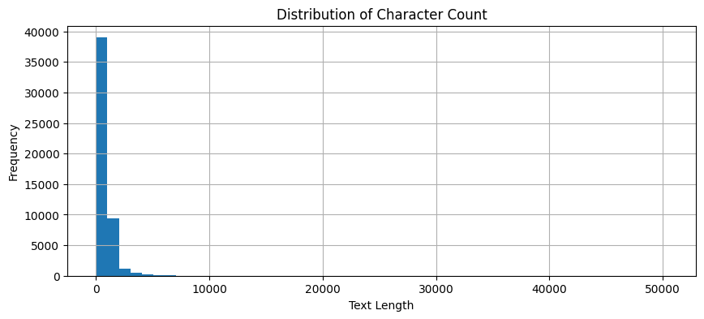

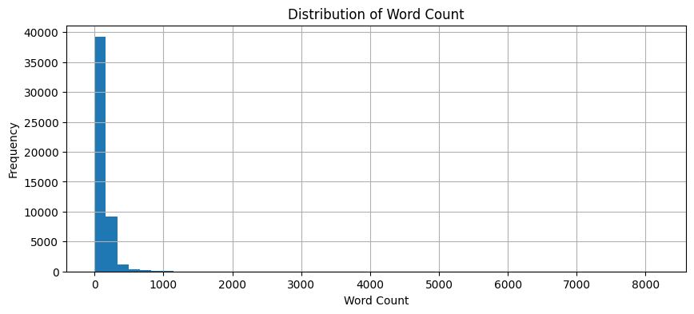

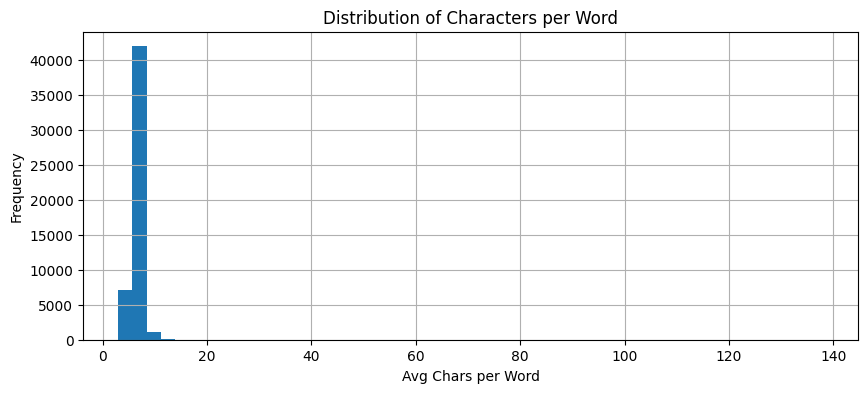

```python
# EDA on the text field
data.loc[:,'char_count'] = data.loc[:,'description'].apply(len)
data.loc[:,'word_count'] = data.loc[:,'description'].apply(lambda x: len(x.split()))
data.loc[:,'chars_per_word'] = data.loc[:,'char_count'] / data.loc[:,'word_count']

def graph_text_word_dist(df):
    # Distribution of text length
    plt.figure(figsize=(10, 4))
    df['char_count'].hist(bins=50)
    plt.title('Distribution of Character Count')
    plt.xlabel('Text Length')
    plt.ylabel('Frequency')
    plt.show()

    # Distribution of word count
    plt.figure(figsize=(10, 4))
    df['word_count'].hist(bins=50)
    plt.title('Distribution of Word Count')
    plt.xlabel('Word Count')
    plt.ylabel('Frequency')
    plt.show()

    # Distribution of characters per word
    plt.figure(figsize=(10, 4))
    df['chars_per_word'].hist(bins=50)
    plt.title('Distribution of Characters per Word')
    plt.xlabel('Avg Chars per Word')
    plt.ylabel('Frequency')
    plt.show()

graph_text_word_dist(data)
```

Below, we are checking anything that has a character length greater then 10,000. Most of these fall in the Books category and tend ot be reviews that are very long. We can proceed with leaving these in the data as they do have important features.

```python
print(data[data['char_count']>10000]['label'].value_counts())
display(data[data['char_count']>10000])
```

```
label
Books          51
Electronics     4
Name: count, dtype: int64
```

|  | label | description | char_count | word_count | chars_per_word |
| --- | --- | --- | --- | --- | --- |
| 122 | Books | The Overlocker Technique Manual: The Complete Guide to Serging and Decorative Stitching Review Aug 2014 This is the third of the books that Search Press sent to me for review purposes. I chose to revi… | 10168 | 1791 | 5.677275 |
| 19839 | Books | Fault Lines – How Hidden Fractures Still Threaten the World Economy Review * Raghuram G. Rajan, Winner of the 2013 Deutsche Bank Prize in Financial Economics, The Center for Financial Studies * Winner… | 12387 | 1910 | 6.485340 |
| 19859 | Books | The Forty Rules of Love: A Novel of Rumi About the Author Elif Shafak is an award-winning bestselling novelist and the most widely read female writer in Turkey. Her books have been translated into mor… | 29751 | 5028 | 5.917064 |
| 19878 | Books | Circe: The Sunday Times Bestseller Review Circe gives us a feminist slant on the Odyssey ... Miller makes these age-old texts thrum with contemporary relevance ... An airy delight, a novel to be gobbl… | 12573 | 2100 | 5.987143 |
| 20386 | Books | How to Be a Bawse: A Guide to Conquering Life Review “Singh segues from her inspirational and uber-watched YouTube videos to essays on how to become a bawse, that is, a supremely self-confident person… | 14870 | 2645 | 5.621928 |
| 20692 | Books | Our Mathematical Universe Review “This is science writing at its best—dynamic, dramatic and accessible. . . . Our Mathematical Universe is nothing if not impressive. Brilliantly argued and beautifully… | 10644 | 1654 | 6.435308 |
| 20720 | Books | Our Mathematical Universe: My Quest for the Ultimate Nature of Reality Review Brian Greene, physicist, author of The Elegant Universe and The Hidden Reality“Our Mathematical Universe boldly confronts … | 10653 | 1630 | 6.535583 |
| 20996 | Books | The Loney Review Winner of the Costa First Novel AwardA "Sunday Times" Exceptional Novel of 2015A Best Book of 2015 by the "Times "and the "Daily Mail" A palpable pall of menace hangs over British aut… | 10001 | 1632 | 6.128064 |
| 22008 | Books | Crazy Rich Asians Review "A dizzily shopaholic comedy of crass manners . . . Crazy Rich Asians offers refreshing nouveau voyeurism to readers who long ago burned out on American and English aspiration… | 12291 | 1979 | 6.210712 |
| 22920 | Books | Dracula (Enriched Classics) About the Author Bram Stoker was born November 8, 1847, in Dublin, Ireland. Stoker was a sickly child who was frequently bedridden; his mother entertained him by telling fr… | 31430 | 5853 | 5.369896 |
| 23091 | Books | Thinking, Fast and Slow Review “A tour de force. . . Kahneman's book is a must read for anyone interested in either human behavior or investing. He clearly shows that while we like to think of ourselv… | 12686 | 2011 | 6.308304 |
| 23466 | Books | Thinking, Fast and Slow Review “A tour de force. . . Kahneman's book is a must read for anyone interested in either human behavior or investing. He clearly shows that while we like to think of ourselv… | 12686 | 2011 | 6.308304 |
| 23490 | Books | Fault Lines – How Hidden Fractures Still Threaten the World Economy Review * Raghuram G. Rajan, Winner of the 2013 Deutsche Bank Prize in Financial Economics, The Center for Financial Studies * Winner… | 12387 | 1910 | 6.485340 |
| 23732 | Books | Ayurveda Lifestyle Wisdom: A Complete Prescription to Optimize Your Health, Prevent Disease, and Live with Vitality and Joy (The Godmothers) Review "Shunya, president of the California Association of … | 11927 | 1828 | 6.524617 |
| 23737 | Books | Ayurveda Lifestyle Wisdom: A Complete Prescription to Optimize Your Health, Prevent Disease, and Live with Vitality and Joy (The Godmothers) Review "Shunya, president of the California Association of … | 11927 | 1828 | 6.524617 |
| 24125 | Books | Life Without Limits: Inspiration for a Ridiculously Good Life About the Author NICK VUJICIC is a motivational speaker and the director founding President of the a non-profit organization, Life Without… | 14728 | 2644 | 5.570348 |
| 24396 | Books | The Forty Rules of Love: A Novel of Rumi About the Author Elif Shafak is an award-winning bestselling novelist and the most widely read female writer in Turkey. Her books have been translated into mor… | 29751 | 5028 | 5.917064 |
| 24524 | Books | The Global War on Christians: Dispatches from the Front Lines of Anti-Christian Persecution About the Author John L. Allen Jr. is associate editor of The Boston Globe after 16 years as the prize-winni… | 47114 | 7724 | 6.099689 |
| 24764 | Books | K2: Life and Death on the World's Most Dangerous Mountain About the Author In May 2005 Ed Viesturs became the first American to ascend all fourteen of the world's 8,000-meter peaks. He lives in Bainbr… | 10518 | 1837 | 5.725640 |
| 24782 | Books | K2: Life and Death on the World's Most Dangerous Mountain About the Author In May 2005 Ed Viesturs became the first American to ascend all fourteen of the world's 8,000-meter peaks. He lives in Bainbr… | 10506 | 1834 | 5.728462 |
| 24794 | Books | Thinking, Fast and Slow Review “A tour de force. . . Kahneman's book is a must read for anyone interested in either human behavior or investing. He clearly shows that while we like to think of ourselv… | 12686 | 2011 | 6.308304 |
| 25798 | Books | Striking Back: The 1972 Munich Olympics Massacre and Israel's Deadly Response About the Author Aaron J. Klein is Time magazine’s Military and Intelligence Affairs correspondent in the Jerusalem Bureau… | 10371 | 1750 | 5.926286 |
| 25950 | Books | Barbarian Days: A Surfing Life Review “How many ways can you describe a wave? You’ll never get tired of watching Finnegan do it. A staff writer at The New Yorker, he leads a counterlife as an obsessiv… | 13048 | 2052 | 6.358674 |
| 26017 | Books | Barbarian Days: A Surfing Life Review “How many ways can you describe a wave? You’ll never get tired of watching Finnegan do it. A staff writer at The New Yorker, he leads a counterlife as an obsessiv… | 13048 | 2052 | 6.358674 |
| 26274 | Books | Leaders Eat Last: Why Some Teams Pull Together and Others Don't About the Author Simon Sinek is an optimist, teacher, writer, and worldwide public speaker. His first four books --Start With Why, Leade… | 14278 | 2544 | 5.612421 |
| 26441 | Books | Thinking, Fast and Slow (International Edition) Review “A tour de force. . . Kahneman's book is a must read for anyone interested in either human behavior or investing. He clearly shows that while we … | 12740 | 2015 | 6.322581 |
| 26457 | Books | Thinking, Fast and Slow (International Edition) Review “A tour de force. . . Kahneman's book is a must read for anyone interested in either human behavior or investing. He clearly shows that while we … | 12740 | 2015 | 6.322581 |
| 26626 | Books | Mastering the Art of Selling Real Estate: Fully Revised and Updated About the Author Tom Hopkins is one of the world’s leading authorities on salesmanship and selling techniques. He has presented his … | 27858 | 5036 | 5.531771 |
| 26635 | Books | The Wall Street Journal. Complete Real-Estate Investing Guidebook (Wall Street Journal Guides) About the Author DAVID CROOK is the editor of The Wall Street Journal Sunday, the personal finance sectio… | 11810 | 1999 | 5.907954 |
| 26638 | Books | Mastering the Art of Selling Real Estate: Fully Revised and Updated About the Author Tom Hopkins is one of the world’s leading authorities on salesmanship and selling techniques. He has presented his … | 27858 | 5036 | 5.531771 |
| 26804 | Books | Thank You for Arguing, Third Edition: What Aristotle, Lincoln, and Homer Simpson Can Teach Us About the Art of Persuasion About the Author JAY HEINRICHS spent twenty-six years as a writer, editor, and… | 15484 | 2565 | 6.036647 |
| 27453 | Books | The Humanities in Contemporary Chinese Contexts (The Humanities in Asia) From the Back Cover This book brings together the perspectives of eminent and emerging scholars on contemporary issues relevant… | 10642 | 1602 | 6.642946 |
| 28008 | Books | Quantum Healing: Exploring the Frontiers of Mind/Body Medicine About the Author DEEPAK CHOPRA MD, FACP, is a world renowned pioneer in integrative medicine and personal transformation, the founder of … | 10258 | 1782 | 5.756453 |
| 28315 | Books | The Great Escape – Health, Wealth, and the Origins of Inequality Review Angus Deaton, Winner of the 2015 Nobel Prize in Economics Winner of the 2013 William G. Bowen Award, Industrial Relations Sectio… | 15840 | 2365 | 6.697674 |
| 28316 | Books | Defending Beef: The Case for Sustainable Meat Production Review "Nicolette Hahn Niman, a lawyer, vegetarian and cattle rancher, serves up a well-argued defense of an American icon: the hamburger. Pass… | 20725 | 3258 | 6.361265 |
| 28323 | Books | Risk Savvy: How to Make Good Decisions About the Author GERD GIGERENZER is director of the Max Planck Institute for Human Development in Berlin, and lectures around the world on the importance of risk… | 50328 | 8169 | 6.160852 |
| 28326 | Books | Risk Savvy: How to Make Good Decisions About the Author GERD GIGERENZER is director of the Max Planck Institute for Human Development in Berlin, and lectures around the world on the importance of risk… | 50328 | 8169 | 6.160852 |
| 28329 | Books | Risk Savvy: How to Make Good Decisions About the Author Gerd Gigerenzer is the author of Gut Feelings. He is currently the director of the Max Planck Institute for Human Development in Berlin, Germany… | 50403 | 8181 | 6.160983 |
| 28652 | Books | Get Out Of Your Mind And Into Your Life: The New Acceptance and Commitment Therapy Amazon.com Review Trying to "change" negative thoughts through cognitive gymnastics is like trying to win a war singl… | 10059 | 1657 | 6.070610 |
| 28654 | Books | Get Out Of Your Mind And Into Your Life: The New Acceptance and Commitment Therapy Amazon.com Review Trying to "change" negative thoughts through cognitive gymnastics is like trying to win a war singl… | 10059 | 1657 | 6.070610 |
| 29020 | Books | If Your Adolescent Has Depression or Bipolar Disorder: An Essential Resource for Parents (Adolescent Mental Health Initiative) Review "This small book took a long time to emerge, but was well worth th… | 15993 | 2344 | 6.822952 |
| 29222 | Books | Intuitive Biostatistics Review "I like this book much, I will be "beta-testing" it on my upper-level undergraduate biostatistics class. It fills a great need for my students."--Harriette Phelps, Unive… | 11975 | 1837 | 6.518781 |
| 30317 | Books | Difficult Women Review Praise for Difficult Women "The characters who inhabit Difficult Women . . . aren't just characters. They are our mothers, sisters and partners. They are human. They are us."--U… | 10237 | 1619 | 6.323039 |
| 30352 | Books | Lean In: Women, Work, and the Will to Lead Review Praise for Lean In (#1 National Bestseller) “Honest and brave . . . The new manifesto for women in the workplace.” —Oprah Winfrey “Lean In is an inaug… | 15990 | 2685 | 5.955307 |
| 30537 | Books | AI Superpowers: China, Silicon Valley, and the New World Order Review A New York Times, Wall Street Journal, and USA Today Bestseller! Featured on CBS 60 Minutes Kai-Fu Lee named a Wired Icon, as part… | 13543 | 2158 | 6.275718 |
| 30632 | Books | Thinking, Fast and Slow Review “A tour de force. . . Kahneman's book is a must read for anyone interested in either human behavior or investing. He clearly shows that while we like to think of ourselv… | 12686 | 2011 | 6.308304 |
| 30747 | Books | How to Be a Bawse: A Guide to Conquering Life Review “Singh segues from her inspirational and uber-watched YouTube videos to essays on how to become a bawse, that is, a supremely self-confident person… | 14870 | 2645 | 5.621928 |
| 31077 | Books | Thinking, Fast and Slow Review “A tour de force. . . Kahneman's book is a must read for anyone interested in either human behavior or investing. He clearly shows that while we like to think of ourselv… | 12686 | 2011 | 6.308304 |
| 42329 | Electronics | Quick Heal Total Security Latest Version - 2 PCs, 3 Years (DVD) Style Name:2 Devices, 3 Years (CD/DVD) Product Description Secures your online banking activities, ensures that your children stay safe … | 12473 | 1870 | 6.670053 |
| 42332 | Electronics | Quick Heal Total Security Latest Version - 2 PCs, 3 Years (DVD) Style Name:2 Devices, 3 Years (CD/DVD) Product Description Secures your online banking activities, ensures that your children stay safe … | 12473 | 1870 | 6.670053 |
| 46837 | Electronics | Nikon D5300 24.2MP Digital SLR Camera(Black) with AF-P 18-55 and AF-P DX NIKKOR 70-300mm f/4.5-6.3G VR Kit, Free Camera Bag and 16GB Memory Card Style name:70-300mm lens Image quality, connectivity an… | 11319 | 1703 | 6.646506 |
| 46844 | Electronics | Nikon D5300 24.2MP Digital SLR Camera(Black) with AF-P 18-55 and AF-P DX NIKKOR 70-300mm f/4.5-6.3G VR Kit, Free Camera Bag and 16GB Memory Card Style name:70-300mm lens Image quality, connectivity an… | 11319 | 1703 | 6.646506 |
| 46940 | Books | Deception Point About the Author Dan Brown is the #1 New York Times bestselling author of The Da Vinci Code and, previously, Digital Fortress, Deception Point, and Angels & Demons. He is a graduate of… | 12372 | 1997 | 6.195293 |
| 46962 | Books | Deception Point About the Author Dan Brown is the #1 New York Times bestselling author of The Da Vinci Code and, previously, Digital Fortress, Deception Point, and Angels & Demons. He is a graduate of… | 12372 | 1997 | 6.195293 |
| 47100 | Books | Deception Point About the Author Dan Brown is the #1 New York Times bestselling author of The Da Vinci Code and, previously, Digital Fortress, Deception Point, and Angels & Demons. He is a graduate of… | 12372 | 1997 | 6.195293 |

We also checked the characters per word field as it is unlikely to have extremely long words. What we find is that there are a lot of part numbers with no spaces, or just a lot of white space in some of these, which will be important to remove later on when we perform text cleaning.

```python
pd.set_option('display.max_colwidth', 500)
print(data[data['chars_per_word']>20]['label'].value_counts())
display(data[data['chars_per_word']>20])
```

```
label
Books                     8
Electronics               7
Clothing & Accessories    5
Household                 3
Name: count, dtype: int64
```

|  | label | description | char_count | word_count | chars_per_word |
| --- | --- | --- | --- | --- | --- |
| 6444 | Household | Valance SACD, Import Product Description Latest LP, Valance, by Waylon Speed. Review to come soo... | 549 | 20 | 27.450000 |
| 6447 | Household | Valance SACD, Import Product Description Latest LP, Valance, by Waylon Speed. Review to come soo... | 549 | 20 | 27.450000 |
| 18613 | Household | Snips: Live at Environ Import | 284 | 5 | 56.800000 |
| 24936 | Books | Transportation Import | 276 | 2 | 138.000000 |
| 25954 | Books | Windsurfing Nation Import Label price increase, apologies | 312 | 7 | 44.571429 |
| 25962 | Books | Windsurfing Nation Import Label price increase, apologies | 312 | 7 | 44.571429 |
| 28348 | Books | Medicaid Fraud Dogg Import | 281 | 4 | 70.250000 |
| 28355 | Books | Medicaid Fraud Dogg Import | 281 | 4 | 70.250000 |
| 28544 | Books | Cardiovascular/Respiratory Physiotherapy | 41 | 2 | 20.500000 |
| 28553 | Books | Cardiovascular/Respiratory Physiotherapy | 41 | 2 | 20.500000 |
| 30853 | Books | Curriculum Import | 272 | 2 | 136.000000 |
| 35328 | Clothing & Accessories | Favoroski Men's Slim Fit Party Wear Formal Blazers Favoroski Slim Fit Classy and Trendy Blazers for Men Favoroski is a brand committed to manufacture and produce the most trendy, stylish fashion wear … | 1823 | 89 | 20.483146 |
| 35331 | Clothing & Accessories | Favoroski Men's Slim Fit Party Wear Formal Blazers Favoroski Slim Fit Classy and Trendy Blazers for Men Favoroski Blazer Size Guide Favoroski Men's Blazers Size Chart Blazers Label Size----Size------C… | 1556 | 46 | 33.826087 |
| 35856 | Clothing & Accessories | Favoroski Men's Slim Fit Party Wear Formal Blazers Favoroski Slim Fit Classy and Trendy Blazers for Men Favoroski Blazer Size Guide Favoroski Men's Blazers Size Chart Blazers Label Size----Size------C… | 1556 | 46 | 33.826087 |
| 35935 | Clothing & Accessories | Favoroski Men's Slim Fit Party Wear Formal Blazers Favoroski Slim Fit Classy and Trendy Blazers for Men Favoroski is a brand committed to manufacture and produce the most trendy, stylish fashion wear … | 1823 | 89 | 20.483146 |
| 36838 | Clothing & Accessories | Daughters Of Time Import | 279 | 4 | 69.750000 |
| 40301 | Electronics | Lapkit Replacement Long Life Notebook Laptop Battery for HP MU06 MU09 Spare 593554-001 593553-001 Compatible Models: HP G42/G42-410US/G42-475DX/G42T/G56-100SA/G56-106EA/G56-107SA/G56-108SA/G56-130SA/G… | 1390 | 67 | 20.746269 |
| 43047 | Electronics | Lifestyles of the Laptop Cafe Import | 291 | 6 | 48.500000 |
| 43055 | Electronics | Lifestyles of the Laptop Cafe Import | 291 | 6 | 48.500000 |
| 46948 | Electronics | Flashpoint CD, Original recording remastered Digitally remastered reissue of The Rolling Stones ... | 512 | 15 | 34.133333 |
| 46950 | Electronics | Flashpoint CD, Original recording remastered Digitally remastered reissue of The Rolling Stones ... | 512 | 15 | 34.133333 |
| 47089 | Electronics | Flashpoint CD, Original recording remastered Digitally remastered reissue of The Rolling Stones ... | 512 | 15 | 34.133333 |
| 47109 | Electronics | Flashpoint CD, Original recording remastered Digitally remastered reissue of The Rolling Stones ... | 512 | 15 | 34.133333 |

### Class Frequency and Word Counts by Label

Next we will repeat the above analysis by label to see if we see anything by category. What we find is that most of the skew is in books, with books going up to 50,000 characters. Clothing and Household both had a skew but were still below 10,000 while electronics was similar but had a could records just above 10,000. This makes sense intuitively as a book review can be significantly longer then other forms of media to convince people to buy the full book.

```python
eda_b = data[data['label']=='Books']
eda_c = data[data['label']=='Clothing & Accessories']
eda_e = data[data['label']=='Electronics']
eda_h = data[data['label']=='Household']
```

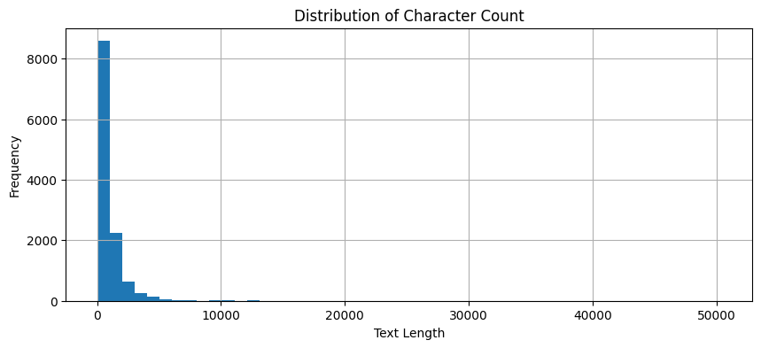

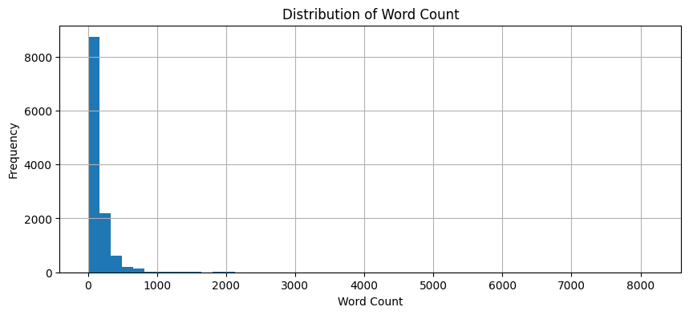

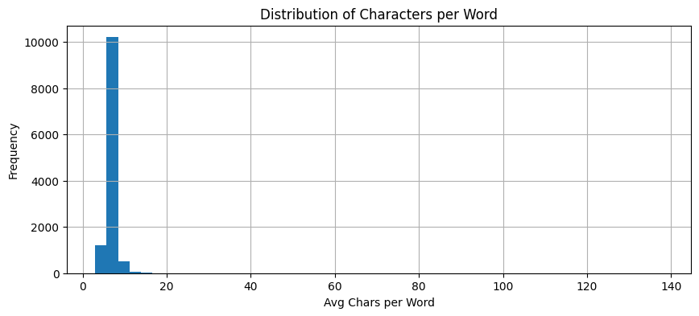

```python
graph_text_word_dist(eda_b)
```

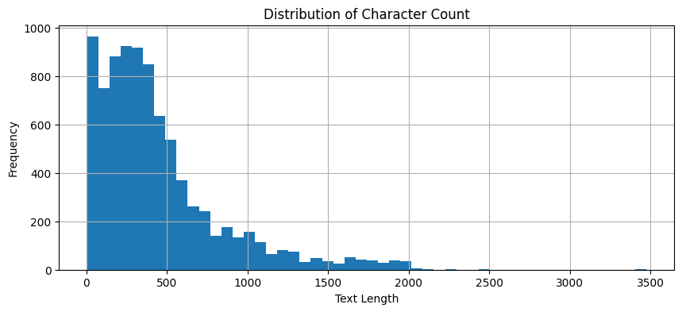

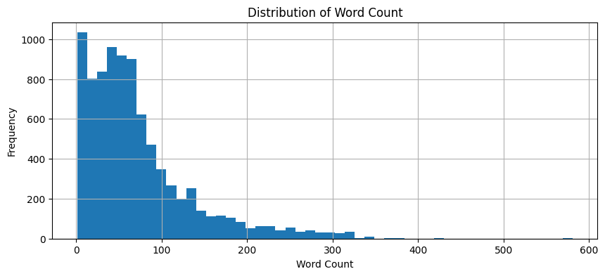

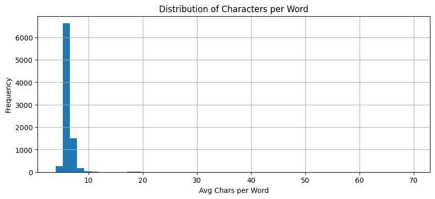

```python
graph_text_word_dist(eda_c)
```

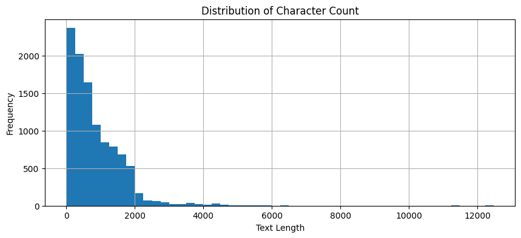

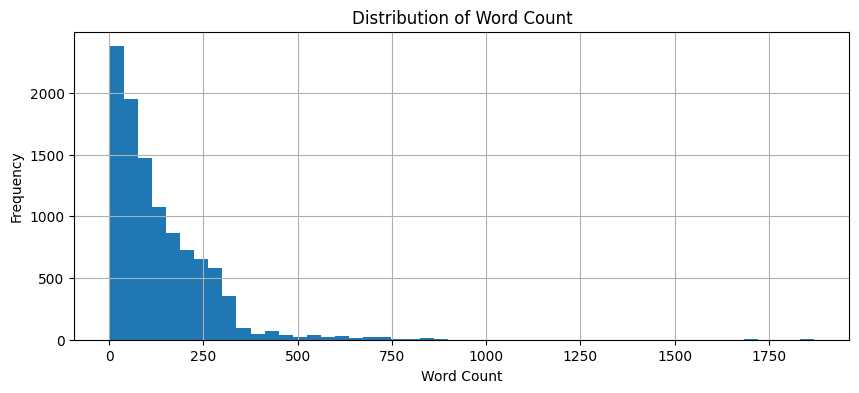

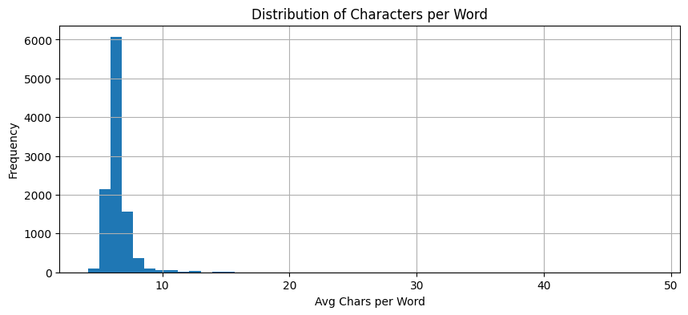

```python
graph_text_word_dist(eda_e)
```

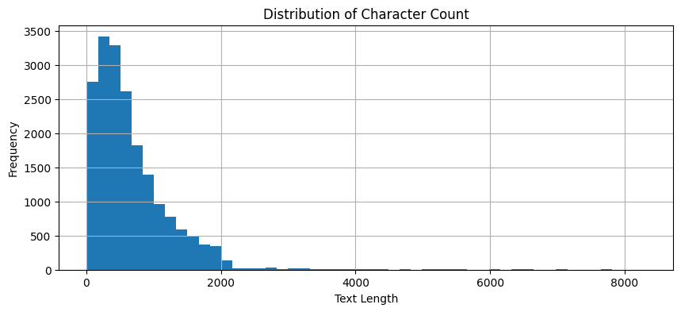

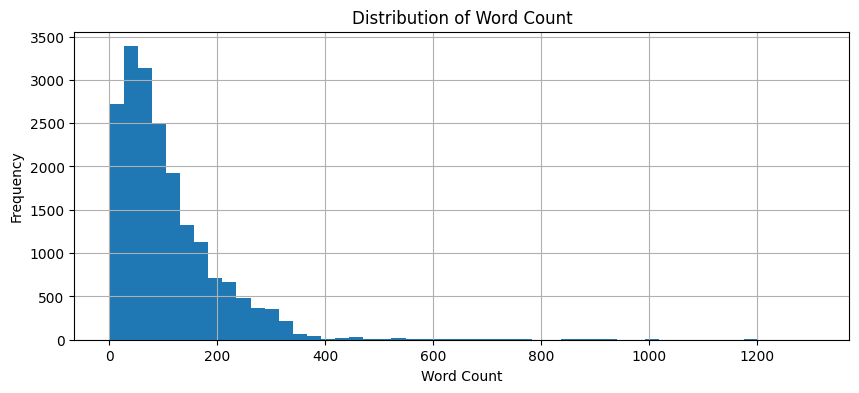

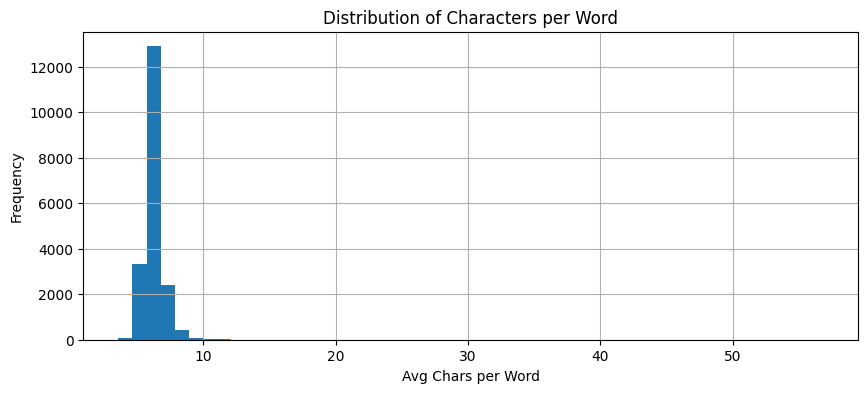

```python
graph_text_word_dist(eda_h)
```

## Text Normalization

Next we will proceed by performing text normalization. In this first phase we will start by performing some basic cleaning. We will set the text to lower case everything and strip out any white space. We will also remove any punctuation and get rid of any HTML addresses that could be causing issues as well. This process is extremely important for allowing the future models to perform effectively. slight differences could cause words to vectorize differently which could throw the model off when it is classifying. Next we will proceed with stop word removal and lemmatization.

```python
text = data['description'].loc[0]
print(f"Input: {text}")

def initial_cleaning(text):
    # Lower Case Text
    text = text.lower()

    # Remove whitespace
    text = text.strip()

    # Remove Punctuation
    punct_str = string.punctuation
    punct_str = punct_str.replace("'", "")
    text = text.translate(str.maketrans("", "", punct_str))

    # Remove HTML Addresses
    html = re.compile(r'<.*?>')
    text = html.sub(r'', text)
    return text

text = initial_cleaning(text)
print(f"Output: {text}")
```

```
Input: Paper Plane Design Framed Wall Hanging Motivational Office Decor Art Prints (8.7 X 8.7 inch) - Set of 4 Painting made up in synthetic frame with uv textured print which gives multi effects and attracts towards it. This is an special series of paintings which makes your wall very beautiful and…
Output: paper plane design framed wall hanging motivational office decor art prints 87 x 87 inch  set of 4 painting made up in synthetic frame with uv textured print which gives multi effects and attracts towards it this is an special series of paintings which makes your wall very beautiful and give…
```

### Stop Words and Lemmatization

Next we will tokenize the text strings and get rid of any remaining non alphabetic characters. This is important as there isnt any reasonable differentiation between an 8 inch picture frame and a 10 inch picture frame. The size of these objects do not matter for categorization. We will also remove stopwords and and lemmatize the text to clean it up and have it reach a more optimal state for working with the data.

```python
# Stopwords
nlp = spacy.load('en_core_web_sm')

def normalize_text(text):
    # Tokenize Text
    words = word_tokenize(text)

    # Remove non-alphabetic words/characters
    words = [word for word in words if word.isalpha()]

    # Remove Stopwords
    stop_words = set(stopwords.words('english'))
    words = [word for word in words if word.isalnum() and word not in stop_words]

    # Lemmatize Text
    doc = nlp(' '.join(words))
    words = [token.lemma_ for token in doc]

    text = ' '.join(words)
    return text

normalized_text = normalize_text(text)
print(f"Output: {normalized_text}")
```

```
Output: paper plane design frame wall hang motivational office decor art print x inch set painting make synthetic frame uv texture print give multi effect attract towards special series painting make wall beautiful give royal touch paint ready hang would proud possess unique painting niche apart use…
```

### Final Function

Finally we will combine the above steps into a single function. I tested it on a few randiom descriptions, and it appears to have worked well over all. I then ran all of the data through the text cleaner.

```python
def clean_text(text):
    text = initial_cleaning(text)
    text = normalize_text(text)
    return text

text = data['description'].loc[10]
print(f"Input: {text}")

cleaned_text = clean_text(text)
print(f"Output: {cleaned_text}")
```

```
Input: Painting Mantra Art Street - Jardin Bird Framed Art Print Set of 4 Black (10 x 10 inch) Color:Color - Black ||Theme - Jardin Black   Breath new life into your home and office with this original painting re-print. These high quality printed canvas are of size 10 inch by 10 inch, comes framed a…
Output: paint mantra art street jardin bird frame art print set black x inch colorcolor black theme jardin black breath new life home office original painting reprint high quality print canvas size inch inch comes frame ready hang note print need glass protection hence come without glass
```

```python
# Apply text cleaning to the 'text' column
tqdm.pandas(desc="Cleaning descriptions")
data.loc[:, 'cleaned_description'] = data.loc[:, 'description'].progress_apply(clean_text)
print("Cleaned description")
display(data[['description', 'cleaned_description']].head())
```

```
Cleaned description
```

|  | description | cleaned_description |
| --- | --- | --- |
| 0 | Paper Plane Design Framed Wall Hanging Motivational Office Decor Art Prints (8.7 X 8.7 inch) - Set of 4 Painting made up in synthetic frame with uv textured print which gives multi effects and attract… | paper plane design frame wall hang motivational office decor art print x inch set painting make synthetic frame uv texture print give multi effect attract towards special series painting make wall bea… |
| 1 | SAF 'Floral' Framed Painting (Wood, 30 inch x 10 inch, Special Effect UV Print Textured, SAO297) Painting made up in synthetic frame with UV textured print which gives multi effects and attracts towar… | saf frame paint wood inch x inch special effect uv print texture painting make synthetic frame uv texture print give multi effect attract towards special series painting make wall beautiful give royal… |
| 2 | SAF 'UV Textured Modern Art Print Framed' Painting (Synthetic, 35 cm x 50 cm x 3 cm, Set of 3) Color:Multicolor \| Size:35 cm x 50 cm x 3 cm Overview a beautiful painting involves the action or skill … | saf texture modern art print frame paint synthetic cm x cm x cm set colormulticolor cm x cm x cm overview beautiful painting involve action skill use paint right manner hence end product picture speak… |
| 3 | SAF Flower Print Framed Painting (Synthetic, 13.5 inch x 22 inch, UV Textured, Set of 3, SANFSW4951) Color:Multicolor \| Size:35 cm x 50 cm x 2 cm A beautiful painting involves the action or skill of … | saf flower print frame paint synthetic inch x inch uv texture set colormulticolor cm x cm x cm beautiful painting involve action skill use paint right manner hence end product picture speak thousand w… |
| 4 | Incredible Gifts India Wooden Happy Birthday Unique Personalized Gift (5 X 4 Inch) Size:4 x 5 Made Of Natural Imported Wood, Which Is Quite Solid With Light Particle Pattern & Is Soft Pale To Blond Co… | incredible gift india wooden happy birthday unique personalized gift x inch x make natural import wood quite solid light particle pattern soft pale blond colour upload photo look amazing beautiful las… |

## Exploratory Data Analysis with Cleaned Data

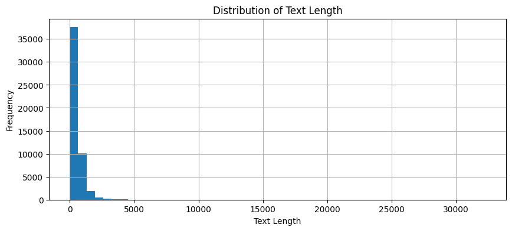

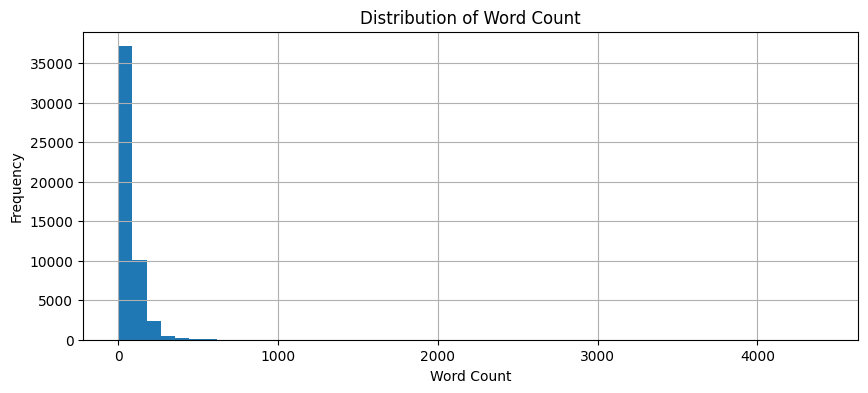

```python
# EDA on the text field
data.loc[:, 'text_length_cleaned'] = data.loc[:, 'cleaned_description'].apply(len)
data.loc[:, 'word_count_cleaned'] = data.loc[:, 'cleaned_description'].apply(lambda x: len(x.split()))

# Distribution of text length
plt.figure(figsize=(10, 4))
data['text_length_cleaned'].hist(bins=50)
plt.title('Distribution of Text Length')
plt.xlabel('Text Length')
plt.ylabel('Frequency')
plt.show()

# Distribution of word count
plt.figure(figsize=(10, 4))
data['word_count_cleaned'].hist(bins=50)
plt.title('Distribution of Word Count')
plt.xlabel('Word Count')
plt.ylabel('Frequency')
plt.show()
```

### Most Common Words

Next lets compare the most common words before and after we did this analysis. Before, the most common words were all filler words and included various capitalizations. Now the most common words include things like book, design, make, use, author which will allow the model to more easily differentiate the categories in the future.

```python
def get_most_common_words(text_series, num_words=30):
    all_words = ' '.join(text_series).split()
    word_counts = Counter(all_words)
    common_words = word_counts.most_common(num_words)
    return common_words

most_common_words_text = get_most_common_words(data['description'])
print("Most Common Words in Original Text:")
print(most_common_words_text)

most_common_words_cleaned_text = get_most_common_words(data['cleaned_description'])
print("Most Common Words in Cleaned Text:")
print(most_common_words_cleaned_text)
```

```
Most Common Words in Original Text:
[('and', 186688), ('the', 173312), ('of', 122125), ('to', 108113), ('a', 87323), ('for', 75847), ('in', 67797), ('is', 66411), ('with', 65059), ('your', 45200), ('The', 38504), ('you', 36084), ('on', 26165), ('that', 25780), ('or', 23798), ('from', 23501), ('it', 22811), ('-', 21978), ('can', 21844)…
Most Common Words in Cleaned Text:
[('make', 25543), ('use', 22871), ('design', 17987), ('book', 17504), ('product', 15016), ('set', 12998), ('x', 12156), ('easy', 11868), ('size', 11307), ('one', 11239), ('quality', 11208), ('also', 11001), ('author', 10788), ('home', 10450), ('high', 10155), ('good', 10136), ('color', 9738), ('feat…
```

## Final Preparation

We will start the final preparation stage by encoding the labels so that they can be properly understood by the model. Since we only have 4 categories, we will manually encode them. We will then limit our dataset to only the new label column and the cleaned_description so the model doesnt see any of the extra columns.

```python
# Manual encoding of labels
label_dict = {'Books': 0, 'Clothing & Accessories': 1, 'Electronics': 2, 'Household': 3}
data.loc[:, 'label_encode'] = data.loc[:, 'label'].map(label_dict)
data.head()
```

|  | label | description | char_count | word_count | chars_per_word | cleaned_description | text_length_cleaned | word_count_cleaned | label_encode |
| --- | --- | --- | --- | --- | --- | --- | --- | --- | --- |
| 0 | Household | Paper Plane Design Framed Wall Hanging Motivational Office Decor Art Prints (8.7 X 8.7 inch) - Set of 4 Painting made up in synthetic frame with uv textured print which gives multi effects and attract… | 1338 | 228 | 5.868421 | paper plane design frame wall hang motivational office decor art print x inch set painting make synthetic frame uv texture print give multi effect attract towards special series painting make wall bea… | 887 | 131 | 3 |
| 1 | Household | SAF 'Floral' Framed Painting (Wood, 30 inch x 10 inch, Special Effect UV Print Textured, SAO297) Painting made up in synthetic frame with UV textured print which gives multi effects and attracts towar… | 346 | 59 | 5.864407 | saf frame paint wood inch x inch special effect uv print texture painting make synthetic frame uv texture print give multi effect attract towards special series painting make wall beautiful give royal… | 231 | 37 | 3 |
| 2 | Household | SAF 'UV Textured Modern Art Print Framed' Painting (Synthetic, 35 cm x 50 cm x 3 cm, Set of 3) Color:Multicolor \| Size:35 cm x 50 cm x 3 cm Overview a beautiful painting involves the action or skill … | 1316 | 224 | 5.875000 | saf texture modern art print frame paint synthetic cm x cm x cm set colormulticolor cm x cm x cm overview beautiful painting involve action skill use paint right manner hence end product picture speak… | 769 | 119 | 3 |
| 3 | Household | SAF Flower Print Framed Painting (Synthetic, 13.5 inch x 22 inch, UV Textured, Set of 3, SANFSW4951) Color:Multicolor \| Size:35 cm x 50 cm x 2 cm A beautiful painting involves the action or skill of … | 1091 | 184 | 5.929348 | saf flower print frame paint synthetic inch x inch uv texture set colormulticolor cm x cm x cm beautiful painting involve action skill use paint right manner hence end product picture speak thousand w… | 616 | 97 | 3 |
| 4 | Household | Incredible Gifts India Wooden Happy Birthday Unique Personalized Gift (5 X 4 Inch) Size:4 x 5 Made Of Natural Imported Wood, Which Is Quite Solid With Light Particle Pattern & Is Soft Pale To Blond Co… | 989 | 184 | 5.375000 | incredible gift india wooden happy birthday unique personalized gift x inch x make natural import wood quite solid light particle pattern soft pale blond colour upload photo look amazing beautiful las… | 593 | 94 | 3 |

```python
final_data = data[['label_encode', 'cleaned_description']]
final_data.columns = ['label', 'description']
final_data.head()
```

|  | label | description |
| --- | --- | --- |
| 0 | 3 | paper plane design frame wall hang motivational office decor art print x inch set painting make synthetic frame uv texture print give multi effect attract towards special series painting make wall bea… |
| 1 | 3 | saf frame paint wood inch x inch special effect uv print texture painting make synthetic frame uv texture print give multi effect attract towards special series painting make wall beautiful give royal… |
| 2 | 3 | saf texture modern art print frame paint synthetic cm x cm x cm set colormulticolor cm x cm x cm overview beautiful painting involve action skill use paint right manner hence end product picture speak… |
| 3 | 3 | saf flower print frame paint synthetic inch x inch uv texture set colormulticolor cm x cm x cm beautiful painting involve action skill use paint right manner hence end product picture speak thousand w… |
| 4 | 3 | incredible gift india wooden happy birthday unique personalized gift x inch x make natural import wood quite solid light particle pattern soft pale blond colour upload photo look amazing beautiful las… |

```python
del data, eda_e, eda_c, eda_b, eda_h
gc.collect()
```

```
13859
```

### Train_Test_Split

Finally, we will split our data into 3 groups. 60% of our data will be used for training the model. 20% for validating that the model is working. and 20% for testing at the end to make sure it did not over fit in the training process.

Once the split is complete, I quickly checked the frequency distribution of the labels to ensure that the data split properly and is fairly evenly distributed.

```python
train_data, temp = train_test_split(final_data, test_size=0.4, random_state=37)
test_data, val_data = train_test_split(temp, test_size=0.5, random_state=37)
del temp, final_data
gc.collect()
```

```
0
```

```python
value_counts = train_data['label'].value_counts()
print(f'Train Data Shape: {test_data.shape}')
print(value_counts)
```

[output not shown]

```python
value_counts = test_data['label'].value_counts()
print(f'Test Data Shape: {test_data.shape}')
print(value_counts)
```

```
Test Data Shape: (10085, 2)
label
3    3876
0    2428
2    2059
1    1722
Name: count, dtype: int64
```

```python
value_counts = val_data['label'].value_counts()
print(f'Validation Data Shape: {val_data.shape}')
print(value_counts)
```

```
Validation Data Shape: (10085, 2)
label
3    3897
0    2377
2    2113
1    1698
Name: count, dtype: int64
```

## Word2Vec Embeddings

In the next phase we will utilize the Google News Word2Vec model to create the embeddings. This works by mapping each distinct word to a vector and assigning the vectors in such a way that the similarity between words is taken into account. In this case, the model was trained off of the Google news corpus which gives access to more formal articles. Additionally, I tested vocab sizes of 10,000, 20,000, and 30,000 and all performed relatively equally. We will use a vocab_size of 10,000 to reduce memory requirements.

- 10,000 accuracy 95.6%
- 20,000 accuracy 95.5%
- 30,000 accuracy 95.5%

Below, we will load in the word2vec model using the gensim library. We will set up the sequences for all 3 datasets so we can proceed through the model building phase later on.

```python
word2vec_model = KeyedVectors.load_word2vec_format(os.path.join('E:\Files\Colorado Masters\DTSA 5511 Intro to Deep Learning\Final',
                                                                'GoogleNews-vectors-negative300.bin'), binary=True)
```

```python
# Step 2: Prepare embedding matrix
vocab_size = 10000  # Define the size of the vocabulary
embedding_dim = 300  # Size of Word2Vec embeddings
tokenizer = Tokenizer(num_words=vocab_size)
tokenizer.fit_on_texts(train_data['description'])
word_index = tokenizer.word_index

embedding_matrix = np.zeros((vocab_size, embedding_dim))
for word, i in word_index.items():
    if i < vocab_size:
        embedding_vector = word2vec_model.get_vector(word) if word in word2vec_model else None
        if embedding_vector is not None:
            embedding_matrix[i] = embedding_vector

# Step 3: Tokenize and pad sequences
max_length = 100  # Define max length of sequences
train_sequences = tokenizer.texts_to_sequences(train_data['description'])
val_sequences = tokenizer.texts_to_sequences(val_data['description'])
test_sequences = tokenizer.texts_to_sequences(test_data['description'])

x_train = pad_sequences(train_sequences, maxlen=max_length, padding='post')
x_val = pad_sequences(val_sequences, maxlen=max_length, padding='post')
x_test = pad_sequences(test_sequences, maxlen=max_length, padding='post')

y_train = train_data['label']
y_val = val_data['label']
y_test = test_data['label']
```

### Build Model

In this stage we will build a basic tensorflow model. We are building it as a function to enable easier hyperparameter tuning later on. This neural network consists of the following:

- Sequential Model - We initiate the model as a sequential model
- Embedding layer - this is where word2vec is implemented
- LSTM Layers - we utilie 2 long short term memory layers to help deal with vanishing gradient problems.
- Dropout layers- the LSTM layers are used in conjunction with dropout layers to randomly ignore nodes and increase nodes to prevent overfitting.
- SoftMax output layer - finally we implement a Dense layer using softmax to output 1 of the 4 classes in the output.

Finally we compile the model using an optimizer and sparse_categorical_crossentropy as the loss function due to the nature of the data.

```python
def build_model(dropout=0.5, optimizer=optimizers.Adam(learning_rate=0.001)):
    if optimizer == None:
        exit()
    else:
        model = keras.Sequential()
        model.add(layers.Embedding(vocab_size, embedding_dim, weights=[embedding_matrix], input_length=max_length, trainable=False))
        model.add(layers.LSTM(128, return_sequences=True))
        model.add(layers.Dropout(0.5))
        model.add(layers.LSTM(64))
        model.add(layers.Dropout(0.5))
        model.add(layers.Dense(4, activation='softmax'))  # Assuming 4 classes in the output

        # Step 6: Compile the model
        model.compile(optimizer= optimizer,
                      loss='sparse_categorical_crossentropy',

                      metrics=['accuracy'])
    return model
```

### Evaluation Function

We also built an evaluation function to create a confusion matrix and calculate the accuracy of the test data after training is complete. This enables us to quickly check the performance of different models and adjustments

```python
def evaluate_model(model, x_test, y_test, label_dict):
    test_loss, test_acc = model.evaluate(x_test, y_test)
    print(f'Test Accuracy: {test_acc}')

    # Generate predictions and confusion matrix
    y_pred = np.argmax(model.predict(x_test), axis=-1)
    cm = confusion_matrix(y_test, y_pred)

    plt.figure(figsize=(8, 6))
    sns.heatmap(cm, annot=True, fmt='d', cmap='Blues', xticklabels=label_dict.keys(), yticklabels=label_dict.keys())
    plt.xlabel('Predicted')
    plt.ylabel('Actual')
    plt.title('Confusion Matrix')
    plt.show()

    # Classification report
    print(classification_report(y_test, y_pred, target_names=label_dict.keys()))
```

### Model Evaluation

Finally we can evaluate the first initial model using Adam as the optimizer. The model trains well and reaches a 95% accuracy right from the start after 10 epochs. This indicates that we are on the right track, but may need to increase the number of epochs and make some adjustments.

```
Test Accuracy: 0.9502230882644653
```

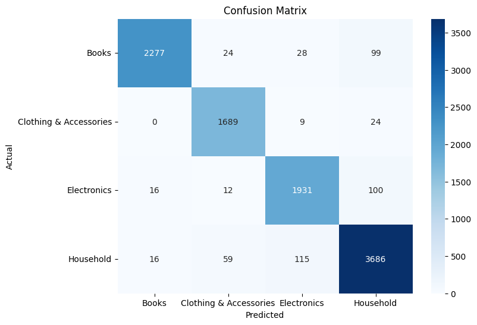

```
                        precision    recall  f1-score   support

                 Books       0.99      0.94      0.96      2428
Clothing & Accessories       0.95      0.98      0.96      1722
           Electronics       0.93      0.94      0.93      2059
             Household       0.94      0.95      0.95      3876

              accuracy                           0.95     10085
             macro avg       0.95      0.95      0.95     10085
          weighted avg       0.95      0.95      0.95     10085
```

```python
model = build_model(dropout=0.5, optimizer=optimizers.Adam(learning_rate=0.001))
history = model.fit(x_train, y_train, epochs=10, batch_size=32, validation_data=(x_val, y_val))
evaluate_model(model, x_test, y_test, label_dict)
```

### Hyperparameter Tuning

Based off the initial findings above, lets proceed to test various things. We will implement the following:

```
Training with batch_size=16, optimizer=<keras.optimizers.optimizer_v2.adam.Adam object at 0x00000253E57AC250>, dropout=0.3
Test Accuracy: 0.9676747918128967
```

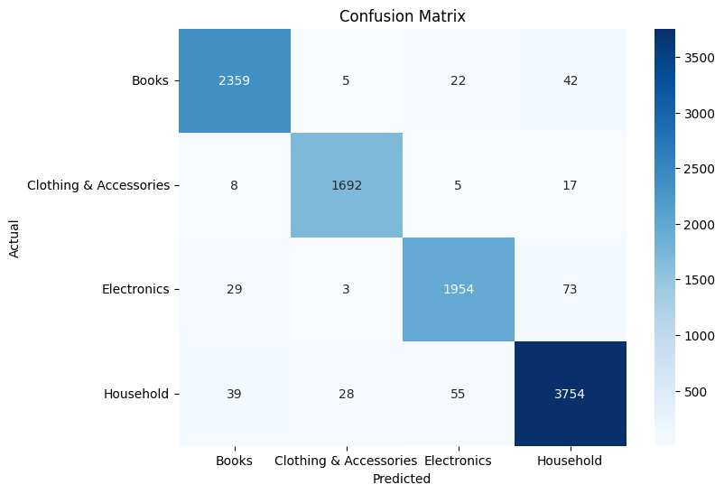

```
                        precision    recall  f1-score   support

                 Books       0.97      0.97      0.97      2428
Clothing & Accessories       0.98      0.98      0.98      1722
           Electronics       0.96      0.95      0.95      2059
             Household       0.97      0.97      0.97      3876

              accuracy                           0.97     10085
             macro avg       0.97      0.97      0.97     10085
          weighted avg       0.97      0.97      0.97     10085

Training with batch_size=16, optimizer=<keras.optimizers.optimizer_v2.adam.Adam object at 0x00000253E57AC250>, dropout=0.5
Test Accuracy: 0.9519087672233582
```

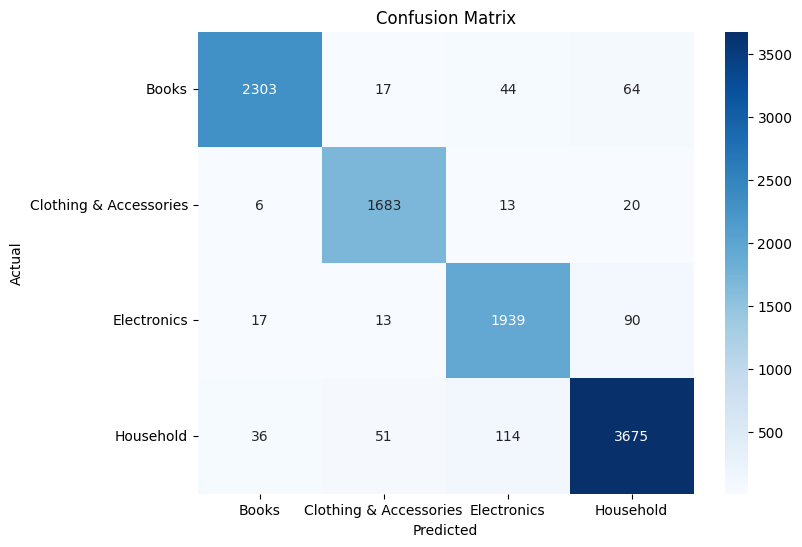

```
                        precision    recall  f1-score   support

                 Books       0.98      0.95      0.96      2428
Clothing & Accessories       0.95      0.98      0.97      1722
           Electronics       0.92      0.94      0.93      2059
             Household       0.95      0.95      0.95      3876

              accuracy                           0.95     10085
             macro avg       0.95      0.95      0.95     10085
          weighted avg       0.95      0.95      0.95     10085

Training with batch_size=16, optimizer=<keras.optimizers.optimizer_v2.rmsprop.RMSprop object at 0x00000253E57A4250>, dropout=0.3
Test Accuracy: 0.9565691351890564
```

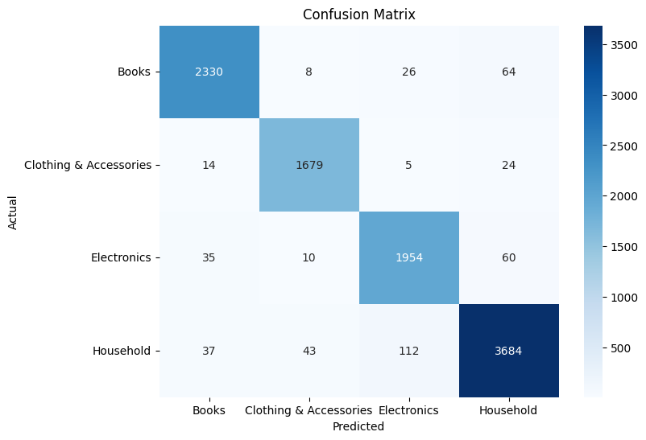

```
                        precision    recall  f1-score   support

                 Books       0.96      0.96      0.96      2428
Clothing & Accessories       0.96      0.98      0.97      1722
           Electronics       0.93      0.95      0.94      2059
             Household       0.96      0.95      0.96      3876

              accuracy                           0.96     10085
             macro avg       0.96      0.96      0.96     10085
          weighted avg       0.96      0.96      0.96     10085

Training with batch_size=16, optimizer=<keras.optimizers.optimizer_v2.rmsprop.RMSprop object at 0x00000253E57A4250>, dropout=0.5
Test Accuracy: 0.9593455791473389
```

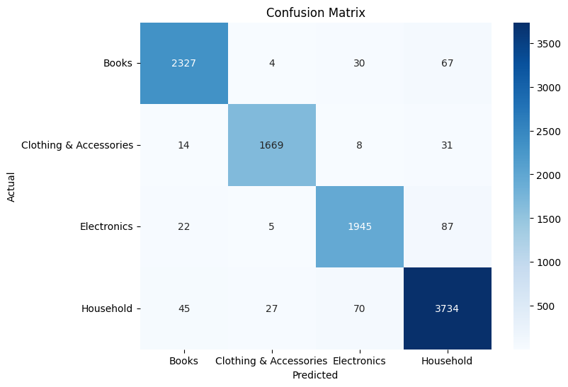

```
                        precision    recall  f1-score   support

                 Books       0.97      0.96      0.96      2428
Clothing & Accessories       0.98      0.97      0.97      1722
           Electronics       0.95      0.94      0.95      2059
             Household       0.95      0.96      0.96      3876

              accuracy                           0.96     10085
             macro avg       0.96      0.96      0.96     10085
          weighted avg       0.96      0.96      0.96     10085

Training with batch_size=32, optimizer=<keras.optimizers.optimizer_v2.adam.Adam object at 0x00000253E57AC250>, dropout=0.3
Test Accuracy: 0.8927119374275208
```

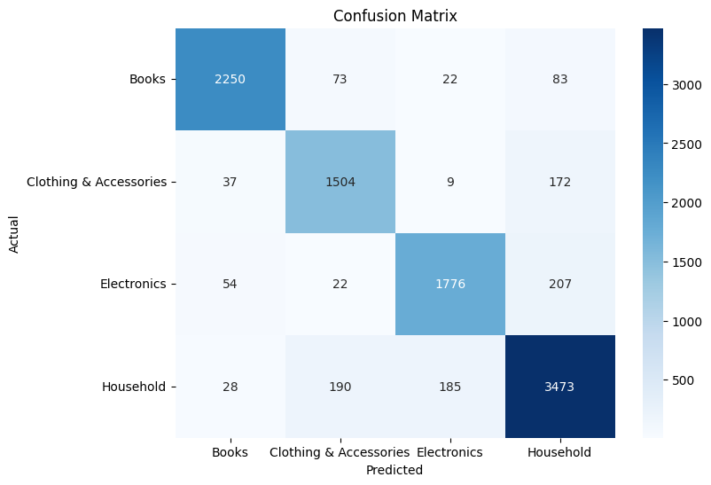

```
                        precision    recall  f1-score   support

                 Books       0.95      0.93      0.94      2428
Clothing & Accessories       0.84      0.87      0.86      1722
           Electronics       0.89      0.86      0.88      2059
             Household       0.88      0.90      0.89      3876

              accuracy                           0.89     10085
             macro avg       0.89      0.89      0.89     10085
          weighted avg       0.89      0.89      0.89     10085

Training with batch_size=32, optimizer=<keras.optimizers.optimizer_v2.adam.Adam object at 0x00000253E57AC250>, dropout=0.5
Test Accuracy: 0.9454635381698608
```

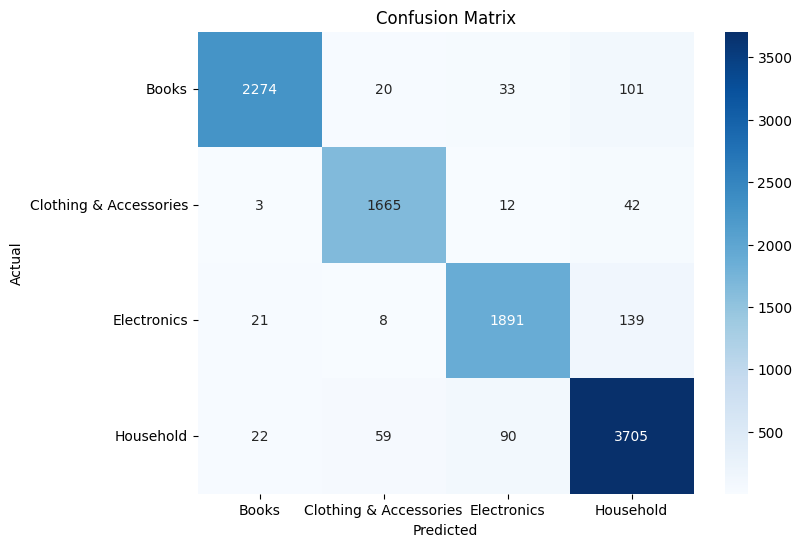

```
                        precision    recall  f1-score   support

                 Books       0.98      0.94      0.96      2428
Clothing & Accessories       0.95      0.97      0.96      1722
           Electronics       0.93      0.92      0.93      2059
             Household       0.93      0.96      0.94      3876

              accuracy                           0.95     10085
             macro avg       0.95      0.94      0.95     10085
          weighted avg       0.95      0.95      0.95     10085

Training with batch_size=32, optimizer=<keras.optimizers.optimizer_v2.rmsprop.RMSprop object at 0x00000253E57A4250>, dropout=0.3
Test Accuracy: 0.9543877243995667
```

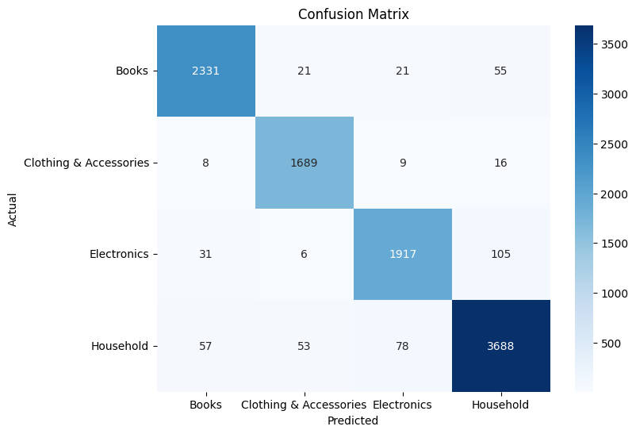

```
                        precision    recall  f1-score   support

                 Books       0.96      0.96      0.96      2428
Clothing & Accessories       0.95      0.98      0.97      1722
           Electronics       0.95      0.93      0.94      2059
             Household       0.95      0.95      0.95      3876

              accuracy                           0.95     10085
             macro avg       0.95      0.96      0.95     10085
          weighted avg       0.95      0.95      0.95     10085

Training with batch_size=32, optimizer=<keras.optimizers.optimizer_v2.rmsprop.RMSprop object at 0x00000253E57A4250>, dropout=0.5
Test Accuracy: 0.9573624134063721
```

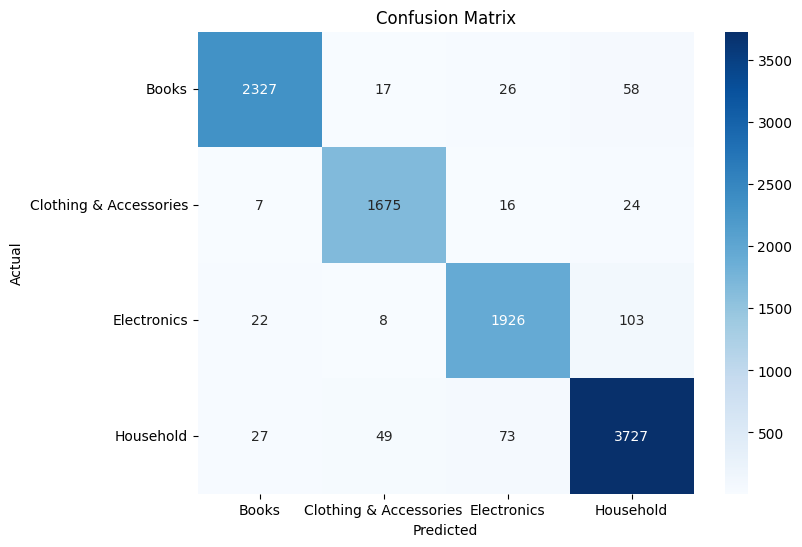

```
                        precision    recall  f1-score   support

                 Books       0.98      0.96      0.97      2428
Clothing & Accessories       0.96      0.97      0.97      1722
           Electronics       0.94      0.94      0.94      2059
             Household       0.95      0.96      0.96      3876

              accuracy                           0.96     10085
             macro avg       0.96      0.96      0.96     10085
          weighted avg       0.96      0.96      0.96     10085
```

```python
# Hyperparameter tuning
batch_sizes = [16, 32]
dropouts = [0.3, 0.5]
optimizers_list = [tf.keras.optimizers.Adam(learning_rate=0.005), tf.keras.optimizers.RMSprop(learning_rate=0.005)]
best_val_acc = 0
best_model = None
results = []

for batch_size in batch_sizes:
    for optimizer in optimizers_list:
        for dropout in dropouts:
            print(f"Training with batch_size={batch_size}, optimizer={optimizer}, dropout={dropout}")
            model = build_model(dropout=dropout, optimizer=optimizer)

            early_stopping = callbacks.EarlyStopping(monitor='val_loss', patience=3, restore_best_weights=True)
            reduce_lr = callbacks.ReduceLROnPlateau(monitor='val_loss', factor=0.2, patience=2, min_lr=0.0001)

            history = model.fit(
                x_train, y_train,
                epochs=20,
                batch_size=batch_size,
                validation_data=(x_val, y_val),
                callbacks=[early_stopping, reduce_lr],
                verbose=1
            )

            val_loss, val_acc = model.evaluate(x_val, y_val)
            test_acc = evaluate_model(model, x_test, y_test, label_dict)
            results.append({
                'batch_size': batch_size,
                'optimizer': optimizer,
                'dropout': dropout,
                'val_acc': val_acc,
            })

            if val_acc > best_val_acc:
                best_val_acc = val_acc
                best_model = model
```

```python
results_df = pd.DataFrame(results)
display(results_df)
```

|  | batch_size | optimizer | dropout | val_acc |
| --- | --- | --- | --- | --- |
| 0 | 16 | <keras.optimizers.optimizer_v2.adam.Adam object at 0x00000253E57AC250> | 0.3 | 0.966782 |
| 1 | 16 | <keras.optimizers.optimizer_v2.adam.Adam object at 0x00000253E57AC250> | 0.5 | 0.948042 |
| 2 | 16 | <keras.optimizers.optimizer_v2.rmsprop.RMSprop object at 0x00000253E57A4250> | 0.3 | 0.954784 |
| 3 | 16 | <keras.optimizers.optimizer_v2.rmsprop.RMSprop object at 0x00000253E57A4250> | 0.5 | 0.956569 |
| 4 | 32 | <keras.optimizers.optimizer_v2.adam.Adam object at 0x00000253E57AC250> | 0.3 | 0.893208 |
| 5 | 32 | <keras.optimizers.optimizer_v2.adam.Adam object at 0x00000253E57AC250> | 0.5 | 0.941497 |
| 6 | 32 | <keras.optimizers.optimizer_v2.rmsprop.RMSprop object at 0x00000253E57A4250> | 0.3 | 0.951710 |
| 7 | 32 | <keras.optimizers.optimizer_v2.rmsprop.RMSprop object at 0x00000253E57A4250> | 0.5 | 0.956371 |

```
Test Accuracy: 0.9676747918128967
```

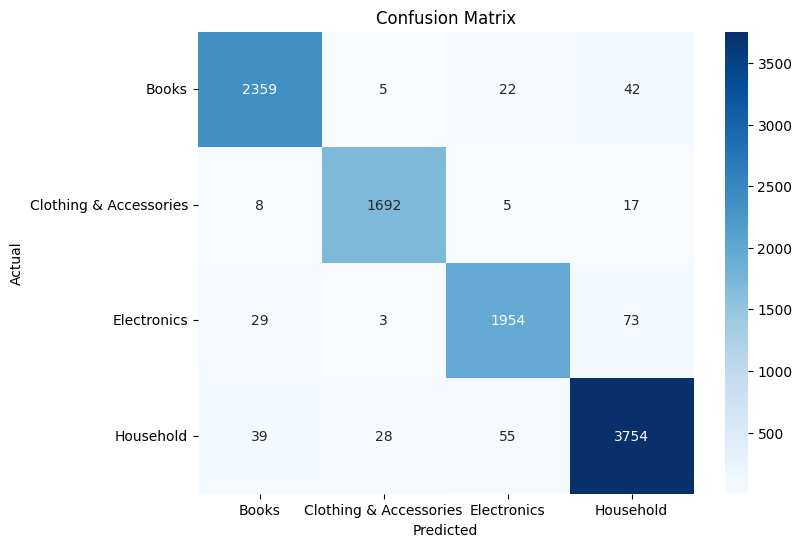

```
                        precision    recall  f1-score   support

                 Books       0.97      0.97      0.97      2428
Clothing & Accessories       0.98      0.98      0.98      1722
           Electronics       0.96      0.95      0.95      2059
             Household       0.97      0.97      0.97      3876

              accuracy                           0.97     10085
             macro avg       0.97      0.97      0.97     10085
          weighted avg       0.97      0.97      0.97     10085
```

```python
evaluate_model(best_model, x_test, y_test, label_dict)
```

## GloVe Embeddings

GloVe is another embedding model that stands for Global Vectors for Word Representation. We will be using the Common Crawl 840B, 2.2M vocab model for training the model. Like Word2Vec this will also use a vocab size of 10,000 due to all performing relatively equally.

An exerpt from the model site explains how the model is trained, " The GloVe model is trained on the non-zero entries of a global word-word co-occurrence matrix, which tabulates how frequently words co-occur with one another in a given corpus. Populating this matrix requires a single pass through the entire corpus to collect the statistic" .J

Jeffrey Pennington, Richard Socher, and Christopher D. Manning. 2014. GloVe: Global Vectors for Word Representation. https://nlp.stanford.edu/projects/glove/

```python
# Function to load GloVe embeddings
def load_glove_embeddings(glove_file_path, embedding_dim, word_index, vocab_size):
    embeddings_index = {}
    with open(glove_file_path, 'r', encoding='utf8') as f:
        for line in f:
            values = line.split()
            word = values[0]
            try:
                coefs = np.asarray(values[1:], dtype='float32')
                embeddings_index[word] = coefs
            except ValueError:
                continue

    embedding_matrix = np.zeros((vocab_size, embedding_dim))
    for word, i in word_index.items():
        if i < vocab_size:
            embedding_vector = embeddings_index.get(word)
            if embedding_vector is not None:
                embedding_matrix[i] = embedding_vector

    return embedding_matrix

glove_file_path = os.path.join('E:\Files\Colorado Masters\DTSA 5511 Intro to Deep Learning\Final', 'glove.840B.300d.txt')
embedding_dim = 300
vocab_size = 10000

# Assuming you have already loaded the dataset and split into train, val, and test sets as in previous code
tokenizer = Tokenizer(num_words=vocab_size)
tokenizer.fit_on_texts(train_data['description'])
word_index = tokenizer.word_index

embedding_matrix = load_glove_embeddings(glove_file_path, embedding_dim, word_index, vocab_size)

# Tokenize and pad sequences
max_length = 100  # Define max length of sequences
train_sequences = tokenizer.texts_to_sequences(train_data['description'])
val_sequences = tokenizer.texts_to_sequences(val_data['description'])
test_sequences = tokenizer.texts_to_sequences(test_data['description'])

x_train = pad_sequences(train_sequences, maxlen=max_length, padding='post')
x_val = pad_sequences(val_sequences, maxlen=max_length, padding='post')
x_test = pad_sequences(test_sequences, maxlen=max_length, padding='post')

y_train = train_data['label']
y_val = val_data['label']
y_test = test_data['label']
```

### Model Training and Tuning

We will utilize the same build_model and evaluate_model functions that we created previously and proceed straight to model training. We will test the same options as we tested in the Word2Vec Model to compare how the different embedding models perform.

```
Training with batch_size=16, optimizer=Adam, dropout=0.3
Test Accuracy: 0.9657907485961914
```

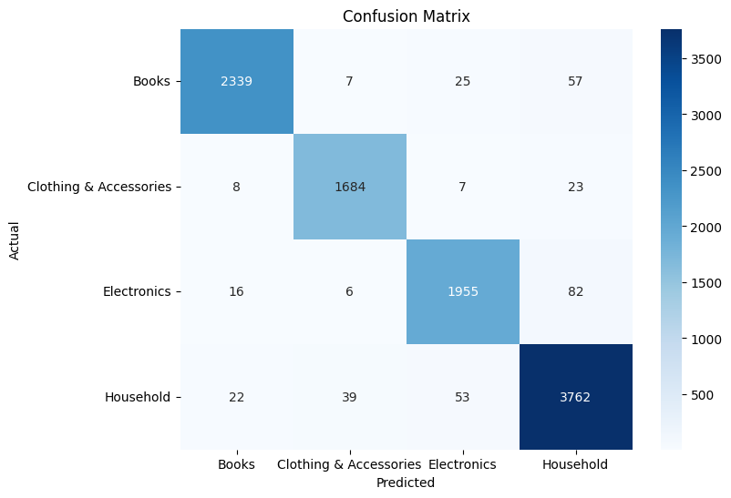

```
                        precision    recall  f1-score   support

                 Books       0.98      0.96      0.97      2428
Clothing & Accessories       0.97      0.98      0.97      1722
           Electronics       0.96      0.95      0.95      2059
             Household       0.96      0.97      0.96      3876

              accuracy                           0.97     10085
             macro avg       0.97      0.97      0.97     10085
          weighted avg       0.97      0.97      0.97     10085

Training with batch_size=16, optimizer=Adam, dropout=0.5
Test Accuracy: 0.9593455791473389
```

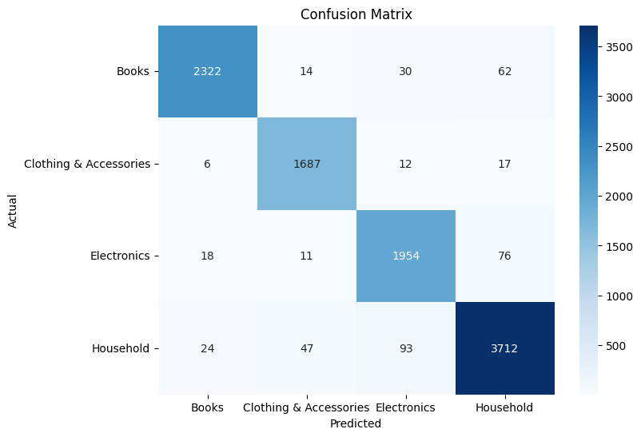

```
                        precision    recall  f1-score   support

                 Books       0.98      0.96      0.97      2428
Clothing & Accessories       0.96      0.98      0.97      1722
           Electronics       0.94      0.95      0.94      2059
             Household       0.96      0.96      0.96      3876

              accuracy                           0.96     10085
             macro avg       0.96      0.96      0.96     10085
          weighted avg       0.96      0.96      0.96     10085

Training with batch_size=16, optimizer=RMSprop, dropout=0.3
Test Accuracy: 0.9647000432014465
```

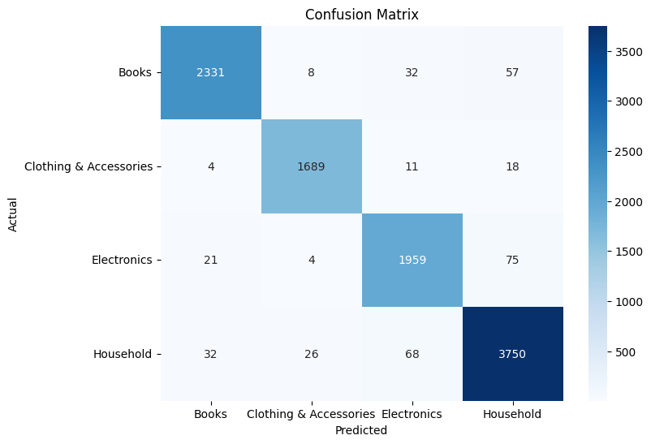

```
                        precision    recall  f1-score   support

                 Books       0.98      0.96      0.97      2428
Clothing & Accessories       0.98      0.98      0.98      1722
           Electronics       0.95      0.95      0.95      2059
             Household       0.96      0.97      0.96      3876

              accuracy                           0.96     10085
             macro avg       0.97      0.96      0.97     10085
          weighted avg       0.96      0.96      0.96     10085

Training with batch_size=16, optimizer=RMSprop, dropout=0.5
Test Accuracy: 0.9632126688957214
```

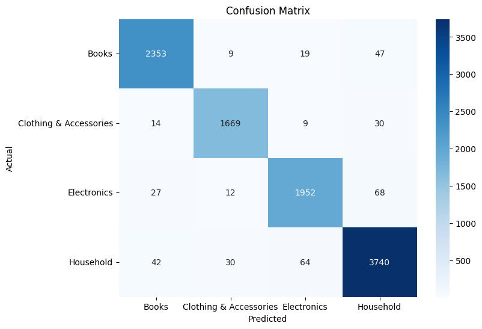

```
                        precision    recall  f1-score   support

                 Books       0.97      0.97      0.97      2428
Clothing & Accessories       0.97      0.97      0.97      1722
           Electronics       0.95      0.95      0.95      2059
             Household       0.96      0.96      0.96      3876

              accuracy                           0.96     10085
             macro avg       0.96      0.96      0.96     10085
          weighted avg       0.96      0.96      0.96     10085

Training with batch_size=32, optimizer=Adam, dropout=0.3
Test Accuracy: 0.9638076424598694
```

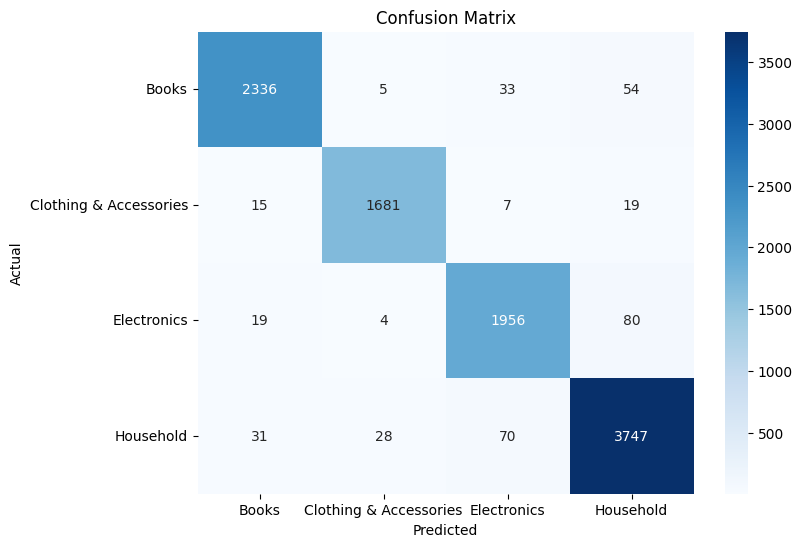

```
                        precision    recall  f1-score   support

                 Books       0.97      0.96      0.97      2428
Clothing & Accessories       0.98      0.98      0.98      1722
           Electronics       0.95      0.95      0.95      2059
             Household       0.96      0.97      0.96      3876

              accuracy                           0.96     10085
             macro avg       0.96      0.96      0.96     10085
          weighted avg       0.96      0.96      0.96     10085

Training with batch_size=32, optimizer=Adam, dropout=0.5
Test Accuracy: 0.9355478286743164
```

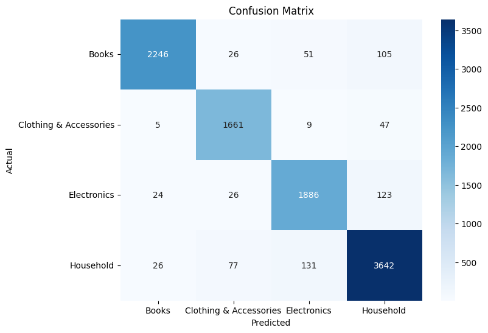

```
                        precision    recall  f1-score   support

                 Books       0.98      0.93      0.95      2428
Clothing & Accessories       0.93      0.96      0.95      1722
           Electronics       0.91      0.92      0.91      2059
             Household       0.93      0.94      0.93      3876

              accuracy                           0.94     10085
             macro avg       0.94      0.94      0.94     10085
          weighted avg       0.94      0.94      0.94     10085

Training with batch_size=32, optimizer=RMSprop, dropout=0.3
Test Accuracy: 0.9623202681541443
```

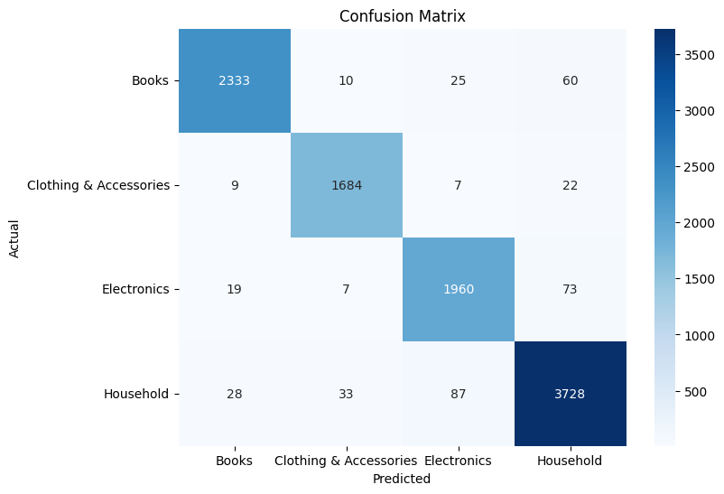

```
                        precision    recall  f1-score   support

                 Books       0.98      0.96      0.97      2428
Clothing & Accessories       0.97      0.98      0.97      1722
           Electronics       0.94      0.95      0.95      2059
             Household       0.96      0.96      0.96      3876

              accuracy                           0.96     10085
             macro avg       0.96      0.96      0.96     10085
          weighted avg       0.96      0.96      0.96     10085

Training with batch_size=32, optimizer=RMSprop, dropout=0.5
Test Accuracy: 0.9587506055831909
```

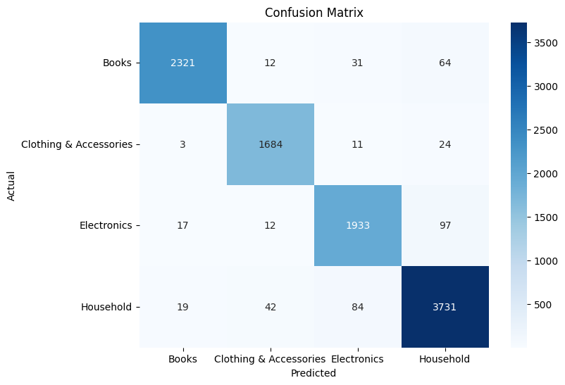

```
                        precision    recall  f1-score   support

                 Books       0.98      0.96      0.97      2428
Clothing & Accessories       0.96      0.98      0.97      1722
           Electronics       0.94      0.94      0.94      2059
             Household       0.95      0.96      0.96      3876

              accuracy                           0.96     10085
             macro avg       0.96      0.96      0.96     10085
          weighted avg       0.96      0.96      0.96     10085
```

```python
# Hyperparameter tuning
batch_sizes = [16, 32]
dropouts = [0.3, 0.5]
optimizers_list = [tf.keras.optimizers.Adam(learning_rate=0.005), tf.keras.optimizers.RMSprop(learning_rate=0.005)]
best_val_acc = 0
best_model = None
results = []

for batch_size in batch_sizes:
    for optimizer in optimizers_list:
        for dropout in dropouts:
            optimizer_name = type(optimizer).__name__
            print(f"Training with batch_size={batch_size}, optimizer={optimizer_name}, dropout={dropout}")
            model = build_model(dropout=dropout, optimizer=optimizer)

            early_stopping = callbacks.EarlyStopping(monitor='val_loss', patience=3, restore_best_weights=True)
            reduce_lr = callbacks.ReduceLROnPlateau(monitor='val_loss', factor=0.2, patience=2, min_lr=0.0001)

            history = model.fit(
                x_train, y_train,
                epochs=20,
                batch_size=batch_size,
                validation_data=(x_val, y_val),
                callbacks=[early_stopping, reduce_lr],
                verbose=1
            )

            val_loss, val_acc = model.evaluate(x_val, y_val)
            test_acc = evaluate_model(model, x_test, y_test, label_dict)
            results.append({
                'batch_size': batch_size,
                'optimizer': optimizer,
                'dropout': dropout,
                'val_acc': val_acc
            })

            if val_acc > best_val_acc:
                best_val_acc = val_acc
                best_model = model
```

```python
# Convert results to a DataFrame
results_df = pd.DataFrame(results)
display(results_df)
```

|  | batch_size | optimizer | dropout | val_acc |
| --- | --- | --- | --- | --- |
| 0 | 16 | <keras.optimizers.optimizer_v2.adam.Adam object at 0x00000253AFCE6C70> | 0.3 | 0.967873 |
| 1 | 16 | <keras.optimizers.optimizer_v2.adam.Adam object at 0x00000253AFCE6C70> | 0.5 | 0.956173 |
| 2 | 16 | <keras.optimizers.optimizer_v2.rmsprop.RMSprop object at 0x00000253EB1859D0> | 0.3 | 0.962221 |
| 3 | 16 | <keras.optimizers.optimizer_v2.rmsprop.RMSprop object at 0x00000253EB1859D0> | 0.5 | 0.961428 |
| 4 | 32 | <keras.optimizers.optimizer_v2.adam.Adam object at 0x00000253AFCE6C70> | 0.3 | 0.959544 |
| 5 | 32 | <keras.optimizers.optimizer_v2.adam.Adam object at 0x00000253AFCE6C70> | 0.5 | 0.934259 |
| 6 | 32 | <keras.optimizers.optimizer_v2.rmsprop.RMSprop object at 0x00000253EB1859D0> | 0.3 | 0.962023 |
| 7 | 32 | <keras.optimizers.optimizer_v2.rmsprop.RMSprop object at 0x00000253EB1859D0> | 0.5 | 0.957164 |

```
Test Accuracy: 0.9657907485961914
```

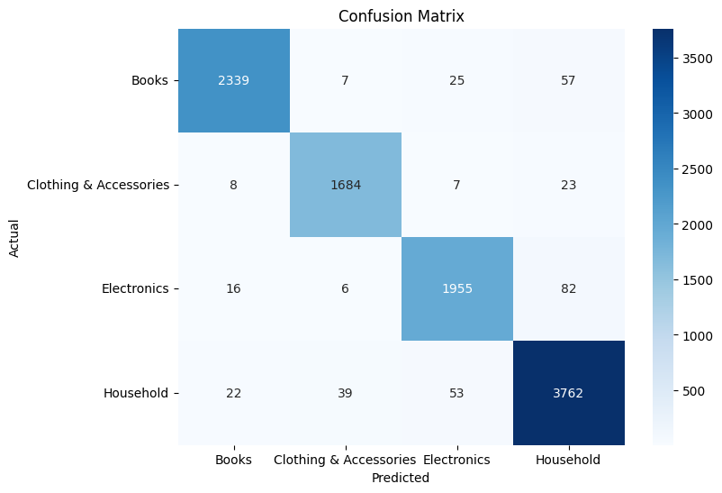

```
                        precision    recall  f1-score   support

                 Books       0.98      0.96      0.97      2428
Clothing & Accessories       0.97      0.98      0.97      1722
           Electronics       0.96      0.95      0.95      2059
             Household       0.96      0.97      0.96      3876

              accuracy                           0.97     10085
             macro avg       0.97      0.97      0.97     10085
          weighted avg       0.97      0.97      0.97     10085
```

```python
evaluate_model(best_model, x_test, y_test, label_dict)
```

## Conclusion

We started this project by performing an EDA do discover key insights into this dataset. We then went on to clean the description column, removing unnecessary information, stop words, and more to aid the model in classifying the data. We then went on to utilizing embedding to vectorize the words to find similarity between descriptions and finally classify the descriptions using a sequential model with tensorflow. throughout this project we have learned how to properly apply embeddings to create a model that can properly classify this data.

### Future Improvements

This model can likely still be improved. Some things we could do to improve the model include looking into better word embeddings. Things like ADA-002 from OpenAI and other more recent embedding models could perform better on the dataset. We could also look further into tuning the model to use different layers to improve the performance.